# Лабораторная работа № 3. Transfer Learning для классификации отходов

**Цель:** сравнить обучение четырёх свёрточных нейросетей со случайной инициализацией и с предобученными на ImageNet весами.

**Модели:** EfficientNet-V2-S, DenseNet121, ResNet18, MobileNetV2. Для каждой — два эксперимента, всего **8**. Основная метрика — **Macro F1-score**.

Датасет [Garbage Classification](https://www.kaggle.com/datasets/asdasdasasdas/garbage-classification) делится один раз со стратификацией на Train / Validation / Test = **70% / 15% / 15%**. Состав выборок не меняется между моделями.

## 1. Установка и настройки

В Google Colab выберите GPU (желательно T4 или мощнее). `SCRATCH_MAX_EPOCHS = 50` — верхняя граница, а не обязательное количество: ранняя остановка прекращает обучение, если валидационный Macro F1 долго не растёт. Для ImageNet-моделей: 2 эпохи обучается классификатор, затем до 18 эпох — вся модель.

```python
%pip -q install kagglehub scikit-learn pandas
```

```python
import gc
import hashlib
import json
import os
import random
import time
from pathlib import Path

import kagglehub
import matplotlib.pyplot as plt
import numpy as np
import pandas as pd
import torch
from PIL import Image
from sklearn.metrics import accuracy_score, classification_report, confusion_matrix, f1_score
from sklearn.model_selection import train_test_split
from torch import nn
from torch.utils.data import DataLoader, Subset
from torchvision import datasets, models, transforms
from tqdm.auto import tqdm

SEED = 42
MODEL_NAMES = ['EfficientNet-V2-S', 'DenseNet121', 'ResNet18', 'MobileNetV2']
NUM_CLASSES = 6
NUM_WORKERS = 0          # Устойчивее в Colab; можно увеличить при стабильной работе.
WEIGHT_DECAY = 1e-4
MIN_DELTA = 0.001

# Обучение со случайных весов: не более 50 эпох.
SCRATCH_MAX_EPOCHS = 50
SCRATCH_MIN_EPOCHS = 15
SCRATCH_PATIENCE = 10
SCRATCH_LR = 8e-4

# ImageNet: 2 эпохи обучаем новый классификатор, затем fine-tuning всех слоёв.
HEAD_EPOCHS = 2
FINETUNE_MAX_EPOCHS = 18
FINETUNE_MIN_EPOCHS = 7
FINETUNE_PATIENCE = 7
HEAD_LR = 1e-3
BACKBONE_LR = 1e-4
FINETUNE_HEAD_LR = 5e-4

SAVE_TO_DRIVE = True
MAX_SESSION_MINUTES = 105   # 0 = без ограничения; проверяем между эпохами.

MODEL_CONFIG = {
    'EfficientNet-V2-S': dict(builder=models.efficientnet_v2_s,
                             weights=models.EfficientNet_V2_S_Weights.IMAGENET1K_V1,
                             batch_size=6),
    'DenseNet121': dict(builder=models.densenet121,
                        weights=models.DenseNet121_Weights.IMAGENET1K_V1,
                        batch_size=12),
    'ResNet18': dict(builder=models.resnet18,
                     weights=models.ResNet18_Weights.IMAGENET1K_V1,
                     batch_size=32),
    'MobileNetV2': dict(builder=models.mobilenet_v2,
                       weights=models.MobileNet_V2_Weights.IMAGENET1K_V2,
                       batch_size=32),
}

def set_seed(seed):
    random.seed(seed)
    np.random.seed(seed)
    torch.manual_seed(seed)
    if torch.cuda.is_available():
        torch.cuda.manual_seed_all(seed)

set_seed(SEED)
device = torch.device('cuda' if torch.cuda.is_available() else 'cpu')
USE_AMP = device.type == 'cuda'
print('PyTorch:', torch.__version__, '| GPU:', torch.cuda.get_device_name(0) if USE_AMP else 'нет')

output_root = Path('/content/lab3_selected4_results')
if SAVE_TO_DRIVE:
    from google.colab import drive
    drive.mount('/content/drive')
    output_root = Path('/content/drive/MyDrive/lab3_selected4_results')
output_root.mkdir(parents=True, exist_ok=True)
```

```
PyTorch: 2.14.1+cu130 | GPU: Tesla T4
```

## 2. Датасет и фиксированное разделение

Разделяем изображения **по индексам** с `SEED=42`. Стратификация сохраняет приблизительную долю каждого класса в трёх выборках. Тестовые изображения не участвуют в обучении весов или выборе лучшей эпохи.

```python
dataset_dir = Path(kagglehub.dataset_download('asdasdasasdas/garbage-classification'))
required_classes = {'cardboard', 'glass', 'metal', 'paper', 'plastic', 'trash'}
image_extensions = {'.jpg', '.jpeg', '.png', '.bmp', '.webp'}

possible_roots = []
for folder in [dataset_dir, *dataset_dir.rglob('*')]:
    if not folder.is_dir():
        continue
    children = {item.name.lower(): item for item in folder.iterdir() if item.is_dir()}
    if not required_classes.issubset(children):
        continue
    count = sum(1 for name in required_classes for file in children[name].rglob('*')
                if file.is_file() and file.suffix.lower() in image_extensions)
    if count:
        possible_roots.append((count, folder))
if not possible_roots:
    raise FileNotFoundError(f'Не найдены папки шести классов внутри {dataset_dir}')
image_root = max(possible_roots, key=lambda item: item[0])[1]

raw_dataset = datasets.ImageFolder(image_root)
class_names = raw_dataset.classes
if set(class_names) != required_classes:
    raise ValueError(f'Неожиданные классы: {class_names}')
labels = np.array(raw_dataset.targets)
all_indices = np.arange(len(labels))

train_indices, heldout_indices = train_test_split(
    all_indices, test_size=0.30, random_state=SEED, stratify=labels)
val_indices, test_indices = train_test_split(
    heldout_indices, test_size=0.50, random_state=SEED,
    stratify=labels[heldout_indices])
assert len(set(train_indices) & set(val_indices)) == 0
assert len(set(train_indices) & set(test_indices)) == 0
assert len(set(val_indices) & set(test_indices)) == 0

print('Классы:', class_names)
print(f'Всего: {len(raw_dataset)} | Train: {len(train_indices)} | '
      f'Val: {len(val_indices)} | Test: {len(test_indices)}')
print('Метка одного изображения:', int(labels[train_indices[0]]))

distribution = pd.DataFrame({
    'Класс': class_names,
    'Train': [(labels[train_indices] == c).sum() for c in range(NUM_CLASSES)],
    'Validation': [(labels[val_indices] == c).sum() for c in range(NUM_CLASSES)],
    'Test': [(labels[test_indices] == c).sum() for c in range(NUM_CLASSES)],
})
display(distribution)

file_signature = hashlib.sha256('\n'.join(
    f'{Path(path).relative_to(image_root).as_posix()}:{label}'
    for path, label in raw_dataset.samples
).encode('utf-8')).hexdigest()

settings = dict(
    seed=SEED, models=MODEL_NAMES, file_signature=file_signature,
    scratch_max=SCRATCH_MAX_EPOCHS, scratch_min=SCRATCH_MIN_EPOCHS,
    scratch_patience=SCRATCH_PATIENCE, scratch_lr=SCRATCH_LR,
    head_epochs=HEAD_EPOCHS, finetune_max=FINETUNE_MAX_EPOCHS,
    finetune_min=FINETUNE_MIN_EPOCHS, finetune_patience=FINETUNE_PATIENCE,
    head_lr=HEAD_LR, backbone_lr=BACKBONE_LR, finetune_head_lr=FINETUNE_HEAD_LR,
    min_delta=MIN_DELTA, weight_decay=WEIGHT_DECAY,
    batches={name: MODEL_CONFIG[name]['batch_size'] for name in MODEL_NAMES},
    weights={name: MODEL_CONFIG[name]['weights'].name for name in MODEL_NAMES},
    transforms='per-model-weights-v1',
)
run_id = hashlib.sha256(json.dumps(settings, sort_keys=True).encode()).hexdigest()[:12]
output_dir = output_root / run_id
output_dir.mkdir(parents=True, exist_ok=True)
(output_dir / 'settings.json').write_text(json.dumps(settings, ensure_ascii=False, indent=2), encoding='utf-8')
print('Папка нового эксперимента:', output_dir)
```

```
Using Colab cache for faster access to the 'garbage-classification' dataset.
Классы: ['cardboard', 'glass', 'metal', 'paper', 'plastic', 'trash']
Всего: 2527 | Train: 1768 | Val: 379 | Test: 380
Метка одного изображения: 4
```

|  | Класс | Train | Validation | Test |
| --- | --- | --- | --- | --- |
| 0 | cardboard | 282 | 61 | 60 |
| 1 | glass | 350 | 75 | 76 |
| 2 | metal | 287 | 61 | 62 |
| 3 | paper | 416 | 89 | 89 |
| 4 | plastic | 337 | 72 | 73 |
| 5 | trash | 96 | 21 | 20 |

```
Папка нового эксперимента: /content/drive/MyDrive/lab3_selected4_results/9e4924cd69e6
```

[figure not shown]

```python
fig, axes = plt.subplots(2, 3, figsize=(10, 6))
for class_id, ax in enumerate(axes.flat):
    sample_index = next(i for i in train_indices if labels[i] == class_id)
    path, _ = raw_dataset.samples[sample_index]
    with Image.open(path) as image:
        ax.imshow(image.convert('RGB'))
    ax.set_title(class_names[class_id])
    ax.axis('off')
plt.tight_layout()
plt.show()
```

## 3. Предобработка и четыре архитектуры

В каждом эксперименте заменяем последний классификатор на слой с **6 выходами**. Для обучения с нуля используем `weights=None`, для переноса — ImageNet-веса. **Внутри каждой пары** (scratch / pretrained) используются одинаковые размеры входа и преобразования. Для EfficientNet-V2-S вход — **384×384**, для остальных — **224×224**. Валидационные преобразования берём из `torchvision` вместе с выбранными весами.

```python
def get_head(model_name, model):
    if model_name == 'ResNet18':
        return model.fc
    return model.classifier


def build_model(model_name, pretrained):
    config = MODEL_CONFIG[model_name]
    model = config['builder'](weights=config['weights'] if pretrained else None)
    if model_name == 'ResNet18':
        model.fc = nn.Linear(model.fc.in_features, NUM_CLASSES)
    elif model_name == 'DenseNet121':
        model.classifier = nn.Linear(model.classifier.in_features, NUM_CLASSES)
    else:
        model.classifier[1] = nn.Linear(model.classifier[1].in_features, NUM_CLASSES)
    return model


def get_loaders(model_name):
    config = MODEL_CONFIG[model_name]
    preset = config['weights'].transforms()
    size = preset.crop_size[0]
    train_transform = transforms.Compose([
        transforms.RandomResizedCrop(size, scale=(0.80, 1.0),
                                     interpolation=preset.interpolation),
        transforms.RandomHorizontalFlip(),
        transforms.ToTensor(),
        transforms.Normalize(preset.mean, preset.std),
    ])
    # Стандартная предобработка для конкретных ImageNet-весов.
    evaluation_transform = preset
    train_dataset = Subset(datasets.ImageFolder(image_root, transform=train_transform),
                           train_indices.tolist())
    val_dataset = Subset(datasets.ImageFolder(image_root, transform=evaluation_transform),
                         val_indices.tolist())
    test_dataset = Subset(datasets.ImageFolder(image_root, transform=evaluation_transform),
                          test_indices.tolist())
    options = dict(batch_size=config['batch_size'], num_workers=NUM_WORKERS,
                   pin_memory=USE_AMP)
    return (DataLoader(train_dataset, shuffle=True, **options),
            DataLoader(val_dataset, shuffle=False, **options),
            DataLoader(test_dataset, shuffle=False, **options))

for model_name in MODEL_NAMES:
    model = build_model(model_name, pretrained=False)
    parameters = sum(p.numel() for p in model.parameters() if p.requires_grad)
    preset = MODEL_CONFIG[model_name]['weights'].transforms()
    print(f'{model_name:18s} | вход 3×{preset.crop_size[0]}×{preset.crop_size[0]} '
          f'| параметров {parameters:,} | batch {MODEL_CONFIG[model_name]["batch_size"]}')
    del model
    gc.collect()

# Проверка одного элемента и батча (для требований к размерностям данных).
example_loader, _, _ = get_loaders('ResNet18')
example_images, example_labels = next(iter(example_loader))
print('Форма изображения:', tuple(example_images[0].shape))
print('Форма батча:', tuple(example_images.shape), '| форма меток:', tuple(example_labels.shape))
del example_loader, example_images, example_labels
```

```
EfficientNet-V2-S  | вход 3×384×384 | параметров 20,185,174 | batch 6
DenseNet121        | вход 3×224×224 | параметров 6,960,006 | batch 12
ResNet18           | вход 3×224×224 | параметров 11,179,590 | batch 32
MobileNetV2        | вход 3×224×224 | параметров 2,231,558 | batch 32
Форма изображения: (3, 224, 224)
Форма батча: (32, 3, 224, 224) | форма меток: (32,)
```

### Кратко об архитектурах

- **ResNet18:** остаточные связи `x + F(x)` облегчают обучение глубоких сетей.
- **MobileNetV2:** глубинные (*depthwise*) и точечные (*pointwise*) свёртки уменьшают вычисления; используются инвертированные остаточные блоки.
- **DenseNet121:** карты признаков предыдущих слоёв конкатенируются по каналам и повторно используются.
- **EfficientNet-V2-S:** комбинирует Fused-MBConv и MBConv с вниманием к каналам; рассчитана на эффективное обучение.

Во всех случаях последняя часть выдаёт **6 логитов**, а CrossEntropyLoss вычисляет ошибку по правильным меткам. В отличие от Accuracy, Macro F1 усредняет F1 каждого класса с равным весом.

## 4. Функции обучения и оценки

Прямой проход → `CrossEntropyLoss` → обратное распространение → обновление AdamW. Для выбора лучшей эпохи измеряем **Macro F1 на валидации**. При вычислении F1 используем предсказания со всей выборки, а не среднее F1 отдельных батчей.

```python
loss_function = nn.CrossEntropyLoss()


def calculate_metrics(y_true, y_pred):
    return dict(
        macro_f1=float(f1_score(y_true, y_pred, average='macro',
                                labels=list(range(NUM_CLASSES)), zero_division=0)),
        accuracy=float(accuracy_score(y_true, y_pred)),
    )


def train_epoch(model, head, loader, optimizer, scaler, head_only=False, label='Train'):
    if head_only:
        model.eval()              # Замороженный backbone, включая BatchNorm.
        head.train()              # Новый классификатор обучается (включая Dropout).
    else:
        model.train()

    total_loss, total_count = 0.0, 0
    y_true, y_pred = [], []
    for images, targets in tqdm(loader, desc=label, leave=False):
        images = images.to(device, non_blocking=True)
        targets = targets.to(device, non_blocking=True)
        optimizer.zero_grad(set_to_none=True)
        with torch.autocast(device_type=device.type, enabled=USE_AMP):
            logits = model(images)
            loss = loss_function(logits, targets)
        scaler.scale(loss).backward()
        scaler.step(optimizer)
        scaler.update()
        total_loss += float(loss.item()) * targets.size(0)
        total_count += targets.size(0)
        y_true.extend(targets.detach().cpu().tolist())
        y_pred.extend(logits.detach().argmax(1).cpu().tolist())
    return dict(loss=total_loss / total_count, **calculate_metrics(y_true, y_pred))


@torch.inference_mode()
def evaluate(model, loader, return_labels=False):
    model.eval()
    total_loss, total_count = 0.0, 0
    y_true, y_pred = [], []
    for images, targets in loader:
        images = images.to(device, non_blocking=True)
        targets = targets.to(device, non_blocking=True)
        with torch.autocast(device_type=device.type, enabled=USE_AMP):
            logits = model(images)
            loss = loss_function(logits, targets)
        total_loss += float(loss.item()) * targets.size(0)
        total_count += targets.size(0)
        y_true.extend(targets.cpu().tolist())
        y_pred.extend(logits.argmax(1).cpu().tolist())
    result = dict(loss=total_loss / total_count, **calculate_metrics(y_true, y_pred))
    if return_labels:
        return result, y_true, y_pred
    return result
```

## 5. Оптимизаторы и Early Stopping

**Scratch:** AdamW, обновляем все веса с первой эпохи, до 50 эпох. После как минимум 15 эпох останавливаемся, если в течение 10 эпох нет улучшения Val Macro F1 хотя бы на 0,001.

**ImageNet:** 2 эпохи обучаем новую голову (`lr=0.001`), затем размораживаем backbone и задаём ему `lr=0.0001`, а голове `lr=0.0005` (до 18 дополнительных эпох). После минимум 7 эпох fine-tuning действует ранняя остановка. Для каждого этапа используем косинусное уменьшение шага.

```python
def make_optimizer(model_name, model, phase):
    head = get_head(model_name, model)
    if phase == 'head':
        for param in model.parameters():
            param.requires_grad_(False)
        for param in head.parameters():
            param.requires_grad_(True)
        optimizer = torch.optim.AdamW(head.parameters(), lr=HEAD_LR,
                                      weight_decay=WEIGHT_DECAY)
        max_epochs = HEAD_EPOCHS
    elif phase == 'finetune':
        for param in model.parameters():
            param.requires_grad_(True)
        head_ids = {id(param) for param in head.parameters()}
        backbone_params = [param for param in model.parameters() if id(param) not in head_ids]
        optimizer = torch.optim.AdamW([
            {'params': backbone_params, 'lr': BACKBONE_LR},
            {'params': list(head.parameters()), 'lr': FINETUNE_HEAD_LR},
        ], weight_decay=WEIGHT_DECAY)
        max_epochs = FINETUNE_MAX_EPOCHS
    elif phase == 'scratch':
        for param in model.parameters():
            param.requires_grad_(True)
        optimizer = torch.optim.AdamW(model.parameters(), lr=SCRATCH_LR,
                                      weight_decay=WEIGHT_DECAY)
        max_epochs = SCRATCH_MAX_EPOCHS
    else:
        raise ValueError(phase)
    scheduler = torch.optim.lr_scheduler.CosineAnnealingLR(
        optimizer, T_max=max_epochs, eta_min=1e-6)
    scaler = torch.amp.GradScaler('cuda', enabled=USE_AMP)
    return optimizer, scheduler, scaler


def checkpoint_paths(model_name, mode):
    folder = output_dir / (model_name.lower().replace('-', '_') + '_' + mode)
    folder.mkdir(parents=True, exist_ok=True)
    return folder / 'last_state.pt', folder / 'best_model.pt'


def atomic_save(obj, path):
    temporary = path.with_name(path.name + '.tmp')
    torch.save(obj, temporary)
    os.replace(temporary, path)


def get_rng_state():
    return dict(python=random.getstate(), torch=torch.get_rng_state(),
                cuda=torch.cuda.get_rng_state_all() if USE_AMP else [])


def restore_rng_state(state):
    if not state:
        return
    random.setstate(state['python'])
    torch.set_rng_state(state['torch'])
    if USE_AMP and state['cuda']:
        torch.cuda.set_rng_state_all(state['cuda'])
```

## 6. Запуск восьми экспериментов

Эксперименты запускаются последовательно. После каждой завершённой эпохи сохраняются состояние модели, AdamW, scheduler и история. Поэтому после разрыва Colab достаточно запустить ноутбук заново с **теми же настройками**: завершённые эксперименты будут пропущены, незавершённый продолжится. Старые результаты других лабораторных сюда не загружаются.

```python
def train_experiment(model_name, mode, deadline=None):
    last_path, best_path = checkpoint_paths(model_name, mode)
    saved = torch.load(last_path, map_location='cpu', weights_only=True) if last_path.exists() else None
    if saved is not None and saved.get('completed', False):
        print(f'{model_name} / {mode}: уже завершено.')
        return saved['summary']

    set_seed(SEED)
    model = build_model(model_name, pretrained=(mode == 'pretrained' and saved is None)).to(device)
    if saved is not None:
        model.load_state_dict(saved['model'])
        print(f'{model_name} / {mode}: восстановлено {len(saved["history"])} эпох.')

    train_loader, val_loader, _ = get_loaders(model_name)
    head = get_head(model_name, model)
    history = list(saved['history']) if saved else []
    best_f1 = float(saved['best_f1']) if saved else -1.0
    best_epoch = int(saved['best_epoch']) if saved else 0
    best_accuracy = float(saved['best_accuracy']) if saved else 0.0
    elapsed_seconds = float(saved.get('elapsed_seconds', 0)) if saved else 0.0
    start_time = time.monotonic()
    phases = [('scratch', SCRATCH_MAX_EPOCHS)] if mode == 'scratch' else [
        ('head', HEAD_EPOCHS), ('finetune', FINETUNE_MAX_EPOCHS)
    ]

    for phase, max_epochs in phases:
        if saved is not None and saved['phase'] != phase:
            if phase == 'head' and saved['phase'] == 'finetune':
                continue
        optimizer, scheduler, scaler = make_optimizer(model_name, model, phase)
        start_phase_epoch = 1
        bad_epochs = 0
        early_reference = best_f1

        if saved is not None and saved['phase'] == phase:
            optimizer.load_state_dict(saved['optimizer'])
            scheduler.load_state_dict(saved['scheduler'])
            scaler.load_state_dict(saved['scaler'])
            start_phase_epoch = saved['phase_epoch'] + 1
            bad_epochs = saved['bad_epochs']
            early_reference = float(saved['early_reference'])
            restore_rng_state(saved.get('rng'))

        for phase_epoch in range(start_phase_epoch, max_epochs + 1):
            if deadline is not None and time.monotonic() >= deadline:
                print('Лимит сеанса достигнут. Состояние сохранено; можно продолжить позже.')
                del model
                gc.collect()
                if USE_AMP:
                    torch.cuda.empty_cache()
                return None

            epoch = len(history) + 1
            train_stats = train_epoch(model, head, train_loader, optimizer, scaler,
                                      head_only=(phase == 'head'),
                                      label=f'{model_name} {mode} · {epoch}')
            val_stats = evaluate(model, val_loader)
            scheduler.step()

            current_f1 = val_stats['macro_f1']
            improved = current_f1 > best_f1
            if improved:
                best_f1 = current_f1
                best_epoch = epoch
                best_accuracy = val_stats['accuracy']
                atomic_save({'model': model.state_dict(), 'epoch': epoch,
                             'val_f1': best_f1, 'val_accuracy': best_accuracy}, best_path)

            # Отдельный порог для Early Stopping, а лучшая модель сохраняется по точному максимуму.
            if phase != 'head':
                if current_f1 > early_reference + MIN_DELTA:
                    early_reference = current_f1
                    bad_epochs = 0
                else:
                    bad_epochs += 1

            history.append(dict(epoch=epoch, phase=phase,
                                train_loss=train_stats['loss'],
                                train_f1=train_stats['macro_f1'],
                                train_accuracy=train_stats['accuracy'],
                                val_loss=val_stats['loss'],
                                val_f1=current_f1,
                                val_accuracy=val_stats['accuracy']))
            print(f'{model_name:18s} {mode:10s} | эпоха {epoch:2d} '
                  f'({phase:8s}) | train F1 {train_stats["macro_f1"]:.4f} | '
                  f'val F1 {current_f1:.4f} | val acc {val_stats["accuracy"]:.2%}'
                  f'{" ★" if improved else ""}', flush=True)

            atomic_save(dict(
                completed=False, phase=phase, phase_epoch=phase_epoch,
                model=model.state_dict(), optimizer=optimizer.state_dict(),
                scheduler=scheduler.state_dict(), scaler=scaler.state_dict(),
                history=history, best_f1=best_f1, best_epoch=best_epoch,
                best_accuracy=best_accuracy, bad_epochs=bad_epochs,
                early_reference=early_reference,
                elapsed_seconds=elapsed_seconds + time.monotonic() - start_time,
                rng=get_rng_state(),
            ), last_path)

            min_epochs = SCRATCH_MIN_EPOCHS if phase == 'scratch' else FINETUNE_MIN_EPOCHS
            patience = SCRATCH_PATIENCE if phase == 'scratch' else FINETUNE_PATIENCE
            if phase != 'head' and phase_epoch >= min_epochs and bad_epochs >= patience:
                print(f'Early Stopping: {patience} эпох без существенного роста Val Macro F1.')
                break

        saved = None  # При смене этапа создаётся новый оптимизатор.

    summary = dict(
        model=model_name, mode=mode, epochs=len(history), best_epoch=best_epoch,
        val_macro_f1=best_f1, val_accuracy=best_accuracy,
        minutes=(elapsed_seconds + time.monotonic() - start_time) / 60,
    )
    atomic_save({'completed': True, 'summary': summary, 'history': history}, last_path)
    (last_path.parent / 'history.json').write_text(
        json.dumps(history, indent=2, ensure_ascii=False), encoding='utf-8')
    del model
    gc.collect()
    if USE_AMP:
        torch.cuda.empty_cache()
    return summary
```

```python
# При ограничении времени обучение остановится между эпохами и продолжится при новом запуске.
deadline = (time.monotonic() + MAX_SESSION_MINUTES * 60) if MAX_SESSION_MINUTES else None
EXPERIMENTS = [(name, 'pretrained') for name in MODEL_NAMES] + [
    (name, 'scratch') for name in MODEL_NAMES
]

summaries = {}
for model_name, mode in EXPERIMENTS:
    print(f'\n{"=" * 72}\n{model_name} / {mode}\n{"=" * 72}')
    result = train_experiment(model_name, mode, deadline=deadline)
    if result is None:
        break
    summaries[(model_name, mode)] = result
    display(pd.DataFrame(summaries.values()).sort_values('val_macro_f1', ascending=False))

print(f'Завершено {len(summaries)} из {len(EXPERIMENTS)} экспериментов.')
if len(summaries) < len(EXPERIMENTS):
    print('Для продолжения перезапустите ноутбук с теми же настройками.')
```

```
========================================================================
EfficientNet-V2-S / pretrained
========================================================================
EfficientNet-V2-S / pretrained: уже завершено.
```

|  | model | mode | epochs | best_epoch | val_macro_f1 | val_accuracy | minutes |
| --- | --- | --- | --- | --- | --- | --- | --- |
| 0 | EfficientNet-V2-S | pretrained | 14 | 7 | 0.939598 | 0.952507 | 14.190967 |

```
========================================================================
DenseNet121 / pretrained
========================================================================
DenseNet121 / pretrained: уже завершено.
```

|  | model | mode | epochs | best_epoch | val_macro_f1 | val_accuracy | minutes |
| --- | --- | --- | --- | --- | --- | --- | --- |
| 0 | EfficientNet-V2-S | pretrained | 14 | 7 | 0.939598 | 0.952507 | 14.190967 |
| 1 | DenseNet121 | pretrained | 20 | 18 | 0.917619 | 0.939314 | 9.273884 |

```
========================================================================
ResNet18 / pretrained
========================================================================
ResNet18 / pretrained: уже завершено.
```

|  | model | mode | epochs | best_epoch | val_macro_f1 | val_accuracy | minutes |
| --- | --- | --- | --- | --- | --- | --- | --- |
| 0 | EfficientNet-V2-S | pretrained | 14 | 7 | 0.939598 | 0.952507 | 14.190967 |
| 1 | DenseNet121 | pretrained | 20 | 18 | 0.917619 | 0.939314 | 9.273884 |
| 2 | ResNet18 | pretrained | 20 | 16 | 0.885356 | 0.907652 | 6.203623 |

```
========================================================================
MobileNetV2 / pretrained
========================================================================
MobileNetV2 / pretrained: уже завершено.
```

|  | model | mode | epochs | best_epoch | val_macro_f1 | val_accuracy | minutes |
| --- | --- | --- | --- | --- | --- | --- | --- |
| 0 | EfficientNet-V2-S | pretrained | 14 | 7 | 0.939598 | 0.952507 | 14.190967 |
| 1 | DenseNet121 | pretrained | 20 | 18 | 0.917619 | 0.939314 | 9.273884 |
| 2 | ResNet18 | pretrained | 20 | 16 | 0.885356 | 0.907652 | 6.203623 |
| 3 | MobileNetV2 | pretrained | 20 | 13 | 0.868774 | 0.894459 | 5.557416 |

```
========================================================================
EfficientNet-V2-S / scratch
========================================================================
EfficientNet-V2-S / scratch: уже завершено.
```

|  | model | mode | epochs | best_epoch | val_macro_f1 | val_accuracy | minutes |
| --- | --- | --- | --- | --- | --- | --- | --- |
| 0 | EfficientNet-V2-S | pretrained | 14 | 7 | 0.939598 | 0.952507 | 14.190967 |
| 1 | DenseNet121 | pretrained | 20 | 18 | 0.917619 | 0.939314 | 9.273884 |
| 2 | ResNet18 | pretrained | 20 | 16 | 0.885356 | 0.907652 | 6.203623 |
| 3 | MobileNetV2 | pretrained | 20 | 13 | 0.868774 | 0.894459 | 5.557416 |
| 4 | EfficientNet-V2-S | scratch | 50 | 49 | 0.665546 | 0.725594 | 54.341134 |

```
========================================================================
DenseNet121 / scratch
========================================================================
DenseNet121 / scratch: восстановлено 30 эпох.
```

```
DenseNet121        scratch    | эпоха 31 (scratch ) | train F1 0.8553 | val F1 0.7426 | val acc 78.36%
```

```
DenseNet121        scratch    | эпоха 32 (scratch ) | train F1 0.8539 | val F1 0.7728 | val acc 81.27% ★
```

```
DenseNet121        scratch    | эпоха 33 (scratch ) | train F1 0.8735 | val F1 0.7973 | val acc 83.11% ★
```

```
DenseNet121        scratch    | эпоха 34 (scratch ) | train F1 0.8820 | val F1 0.7737 | val acc 80.47%
```

```
DenseNet121        scratch    | эпоха 35 (scratch ) | train F1 0.8918 | val F1 0.7680 | val acc 79.16%
```

```
DenseNet121        scratch    | эпоха 36 (scratch ) | train F1 0.9038 | val F1 0.7659 | val acc 80.47%
```

```
DenseNet121        scratch    | эпоха 37 (scratch ) | train F1 0.9069 | val F1 0.8010 | val acc 82.32% ★
```

```
DenseNet121        scratch    | эпоха 38 (scratch ) | train F1 0.9294 | val F1 0.7309 | val acc 78.10%
```

```
DenseNet121        scratch    | эпоха 39 (scratch ) | train F1 0.9257 | val F1 0.8072 | val acc 83.11% ★
```

```
DenseNet121        scratch    | эпоха 40 (scratch ) | train F1 0.9258 | val F1 0.7964 | val acc 83.11%
```

```
DenseNet121        scratch    | эпоха 41 (scratch ) | train F1 0.9493 | val F1 0.7887 | val acc 81.79%
```

```
DenseNet121        scratch    | эпоха 42 (scratch ) | train F1 0.9414 | val F1 0.8013 | val acc 82.59%
```

```
DenseNet121        scratch    | эпоха 43 (scratch ) | train F1 0.9566 | val F1 0.8018 | val acc 82.85%
```

```
DenseNet121        scratch    | эпоха 44 (scratch ) | train F1 0.9481 | val F1 0.7998 | val acc 82.59%
```

```
DenseNet121        scratch    | эпоха 45 (scratch ) | train F1 0.9538 | val F1 0.7851 | val acc 81.27%
```

```
DenseNet121        scratch    | эпоха 46 (scratch ) | train F1 0.9534 | val F1 0.7887 | val acc 82.32%
```

```
DenseNet121        scratch    | эпоха 47 (scratch ) | train F1 0.9599 | val F1 0.7918 | val acc 82.06%
```

```
DenseNet121        scratch    | эпоха 48 (scratch ) | train F1 0.9555 | val F1 0.7992 | val acc 82.85%
```

```
DenseNet121        scratch    | эпоха 49 (scratch ) | train F1 0.9630 | val F1 0.7929 | val acc 82.06%
Early Stopping: 10 эпох без существенного роста Val Macro F1.
```

|  | model | mode | epochs | best_epoch | val_macro_f1 | val_accuracy | minutes |
| --- | --- | --- | --- | --- | --- | --- | --- |
| 0 | EfficientNet-V2-S | pretrained | 14 | 7 | 0.939598 | 0.952507 | 14.190967 |
| 1 | DenseNet121 | pretrained | 20 | 18 | 0.917619 | 0.939314 | 9.273884 |
| 2 | ResNet18 | pretrained | 20 | 16 | 0.885356 | 0.907652 | 6.203623 |
| 3 | MobileNetV2 | pretrained | 20 | 13 | 0.868774 | 0.894459 | 5.557416 |
| 5 | DenseNet121 | scratch | 49 | 39 | 0.807173 | 0.831135 | 25.546264 |
| 4 | EfficientNet-V2-S | scratch | 50 | 49 | 0.665546 | 0.725594 | 54.341134 |

```
========================================================================
ResNet18 / scratch
========================================================================
```

```
ResNet18           scratch    | эпоха  1 (scratch ) | train F1 0.3924 | val F1 0.3942 | val acc 46.17% ★
```

```
ResNet18           scratch    | эпоха  2 (scratch ) | train F1 0.4711 | val F1 0.4771 | val acc 55.67% ★
```

```
ResNet18           scratch    | эпоха  3 (scratch ) | train F1 0.5181 | val F1 0.4293 | val acc 48.02%
```

```
ResNet18           scratch    | эпоха  4 (scratch ) | train F1 0.5286 | val F1 0.3652 | val acc 48.28%
```

```
ResNet18           scratch    | эпоха  5 (scratch ) | train F1 0.5473 | val F1 0.3923 | val acc 46.17%
```

```
ResNet18           scratch    | эпоха  6 (scratch ) | train F1 0.5867 | val F1 0.3450 | val acc 45.12%
```

```
ResNet18           scratch    | эпоха  7 (scratch ) | train F1 0.6141 | val F1 0.5211 | val acc 59.63% ★
```

```
ResNet18           scratch    | эпоха  8 (scratch ) | train F1 0.6210 | val F1 0.5724 | val acc 61.48% ★
```

```
ResNet18           scratch    | эпоха  9 (scratch ) | train F1 0.6736 | val F1 0.5847 | val acc 64.12% ★
```

```
ResNet18           scratch    | эпоха 10 (scratch ) | train F1 0.6594 | val F1 0.4959 | val acc 58.31%
```

```
ResNet18           scratch    | эпоха 11 (scratch ) | train F1 0.7026 | val F1 0.6395 | val acc 67.55% ★
```

```
ResNet18           scratch    | эпоха 12 (scratch ) | train F1 0.6959 | val F1 0.5622 | val acc 63.85%
```

```
ResNet18           scratch    | эпоха 13 (scratch ) | train F1 0.7020 | val F1 0.5429 | val acc 59.37%
```

```
ResNet18           scratch    | эпоха 14 (scratch ) | train F1 0.7312 | val F1 0.5827 | val acc 61.48%
```

```
ResNet18           scratch    | эпоха 15 (scratch ) | train F1 0.7350 | val F1 0.5884 | val acc 64.91%
```

```
ResNet18           scratch    | эпоха 16 (scratch ) | train F1 0.7290 | val F1 0.6236 | val acc 68.07%
```

```
ResNet18           scratch    | эпоха 17 (scratch ) | train F1 0.7566 | val F1 0.6993 | val acc 73.09% ★
```

```
ResNet18           scratch    | эпоха 18 (scratch ) | train F1 0.7726 | val F1 0.5037 | val acc 59.63%
```

```
ResNet18           scratch    | эпоха 19 (scratch ) | train F1 0.7893 | val F1 0.6108 | val acc 65.17%
```

```
ResNet18           scratch    | эпоха 20 (scratch ) | train F1 0.7867 | val F1 0.7028 | val acc 73.88% ★
```

```
ResNet18           scratch    | эпоха 21 (scratch ) | train F1 0.8055 | val F1 0.5059 | val acc 55.94%
```

```
ResNet18           scratch    | эпоха 22 (scratch ) | train F1 0.7841 | val F1 0.6584 | val acc 68.60%
```

```
ResNet18           scratch    | эпоха 23 (scratch ) | train F1 0.8065 | val F1 0.5983 | val acc 67.28%
```

```
ResNet18           scratch    | эпоха 24 (scratch ) | train F1 0.8247 | val F1 0.6921 | val acc 73.61%
```

```
ResNet18           scratch    | эпоха 25 (scratch ) | train F1 0.8340 | val F1 0.5098 | val acc 54.35%
```

```
ResNet18           scratch    | эпоха 26 (scratch ) | train F1 0.8355 | val F1 0.7030 | val acc 72.82% ★
```

```
ResNet18           scratch    | эпоха 27 (scratch ) | train F1 0.8623 | val F1 0.7271 | val acc 76.25% ★
```

```
ResNet18           scratch    | эпоха 28 (scratch ) | train F1 0.8705 | val F1 0.6756 | val acc 72.82%
```

```
ResNet18           scratch    | эпоха 29 (scratch ) | train F1 0.8733 | val F1 0.7368 | val acc 75.99% ★
```

```
ResNet18           scratch    | эпоха 30 (scratch ) | train F1 0.8928 | val F1 0.7395 | val acc 77.57% ★
```

```
ResNet18           scratch    | эпоха 31 (scratch ) | train F1 0.8809 | val F1 0.7151 | val acc 73.61%
```

```
ResNet18           scratch    | эпоха 32 (scratch ) | train F1 0.8801 | val F1 0.6901 | val acc 73.61%
```

```
ResNet18           scratch    | эпоха 33 (scratch ) | train F1 0.9108 | val F1 0.7563 | val acc 77.84% ★
```

```
ResNet18           scratch    | эпоха 34 (scratch ) | train F1 0.9205 | val F1 0.7548 | val acc 78.10%
```

```
ResNet18           scratch    | эпоха 35 (scratch ) | train F1 0.9040 | val F1 0.7510 | val acc 78.36%
```

```
ResNet18           scratch    | эпоха 36 (scratch ) | train F1 0.9309 | val F1 0.7500 | val acc 78.10%
```

```
ResNet18           scratch    | эпоха 37 (scratch ) | train F1 0.9359 | val F1 0.7571 | val acc 78.10% ★
```

```
ResNet18           scratch    | эпоха 38 (scratch ) | train F1 0.9537 | val F1 0.7621 | val acc 79.68% ★
```

```
ResNet18           scratch    | эпоха 39 (scratch ) | train F1 0.9552 | val F1 0.7664 | val acc 79.95% ★
```

```
ResNet18           scratch    | эпоха 40 (scratch ) | train F1 0.9576 | val F1 0.7302 | val acc 76.25%
```

```
ResNet18           scratch    | эпоха 41 (scratch ) | train F1 0.9575 | val F1 0.7449 | val acc 78.63%
```

```
ResNet18           scratch    | эпоха 42 (scratch ) | train F1 0.9700 | val F1 0.7723 | val acc 80.21% ★
```

```
ResNet18           scratch    | эпоха 43 (scratch ) | train F1 0.9696 | val F1 0.7801 | val acc 80.47% ★
```

```
ResNet18           scratch    | эпоха 44 (scratch ) | train F1 0.9698 | val F1 0.7699 | val acc 79.95%
```

```
ResNet18           scratch    | эпоха 45 (scratch ) | train F1 0.9729 | val F1 0.7820 | val acc 80.47% ★
```

```
ResNet18           scratch    | эпоха 46 (scratch ) | train F1 0.9734 | val F1 0.7725 | val acc 80.47%
```

```
ResNet18           scratch    | эпоха 47 (scratch ) | train F1 0.9768 | val F1 0.7595 | val acc 79.68%
```

```
ResNet18           scratch    | эпоха 48 (scratch ) | train F1 0.9737 | val F1 0.7505 | val acc 78.36%
```

```
ResNet18           scratch    | эпоха 49 (scratch ) | train F1 0.9808 | val F1 0.7648 | val acc 79.42%
```

```
ResNet18           scratch    | эпоха 50 (scratch ) | train F1 0.9791 | val F1 0.7741 | val acc 79.95%
```

|  | model | mode | epochs | best_epoch | val_macro_f1 | val_accuracy | minutes |
| --- | --- | --- | --- | --- | --- | --- | --- |
| 0 | EfficientNet-V2-S | pretrained | 14 | 7 | 0.939598 | 0.952507 | 14.190967 |
| 1 | DenseNet121 | pretrained | 20 | 18 | 0.917619 | 0.939314 | 9.273884 |
| 2 | ResNet18 | pretrained | 20 | 16 | 0.885356 | 0.907652 | 6.203623 |
| 3 | MobileNetV2 | pretrained | 20 | 13 | 0.868774 | 0.894459 | 5.557416 |
| 5 | DenseNet121 | scratch | 49 | 39 | 0.807173 | 0.831135 | 25.546264 |
| 6 | ResNet18 | scratch | 50 | 45 | 0.782015 | 0.804749 | 16.433654 |
| 4 | EfficientNet-V2-S | scratch | 50 | 49 | 0.665546 | 0.725594 | 54.341134 |

```
========================================================================
MobileNetV2 / scratch
========================================================================
```

```
MobileNetV2        scratch    | эпоха  1 (scratch ) | train F1 0.3430 | val F1 0.0532 | val acc 19.00% ★
```

```
MobileNetV2        scratch    | эпоха  2 (scratch ) | train F1 0.4444 | val F1 0.5032 | val acc 56.73% ★
```

```
MobileNetV2        scratch    | эпоха  3 (scratch ) | train F1 0.4850 | val F1 0.4433 | val acc 51.19%
```

```
MobileNetV2        scratch    | эпоха  4 (scratch ) | train F1 0.5338 | val F1 0.5000 | val acc 59.10%
```

```
MobileNetV2        scratch    | эпоха  5 (scratch ) | train F1 0.6015 | val F1 0.5653 | val acc 62.01% ★
```

```
MobileNetV2        scratch    | эпоха  6 (scratch ) | train F1 0.6211 | val F1 0.5786 | val acc 64.91% ★
```

```
MobileNetV2        scratch    | эпоха  7 (scratch ) | train F1 0.6526 | val F1 0.5653 | val acc 66.23%
```

```
MobileNetV2        scratch    | эпоха  8 (scratch ) | train F1 0.6317 | val F1 0.5944 | val acc 65.44% ★
```

```
MobileNetV2        scratch    | эпоха  9 (scratch ) | train F1 0.6755 | val F1 0.4983 | val acc 56.99%
```

```
MobileNetV2        scratch    | эпоха 10 (scratch ) | train F1 0.6982 | val F1 0.6526 | val acc 67.28% ★
```

```
MobileNetV2        scratch    | эпоха 11 (scratch ) | train F1 0.7147 | val F1 0.6669 | val acc 70.71% ★
```

```
MobileNetV2        scratch    | эпоха 12 (scratch ) | train F1 0.7114 | val F1 0.6893 | val acc 73.09% ★
```

```
MobileNetV2        scratch    | эпоха 13 (scratch ) | train F1 0.7277 | val F1 0.6596 | val acc 71.50%
```

```
MobileNetV2        scratch    | эпоха 14 (scratch ) | train F1 0.7365 | val F1 0.6177 | val acc 64.64%
```

```
MobileNetV2        scratch    | эпоха 15 (scratch ) | train F1 0.7585 | val F1 0.6379 | val acc 66.49%
```

```
MobileNetV2        scratch    | эпоха 16 (scratch ) | train F1 0.7757 | val F1 0.6767 | val acc 69.92%
```

```
MobileNetV2        scratch    | эпоха 17 (scratch ) | train F1 0.7803 | val F1 0.5593 | val acc 58.84%
```

```
MobileNetV2        scratch    | эпоха 18 (scratch ) | train F1 0.7681 | val F1 0.7604 | val acc 77.31% ★
```

```
MobileNetV2        scratch    | эпоха 19 (scratch ) | train F1 0.8241 | val F1 0.7246 | val acc 76.52%
```

```
MobileNetV2        scratch    | эпоха 20 (scratch ) | train F1 0.8178 | val F1 0.6846 | val acc 71.77%
```

```
MobileNetV2        scratch    | эпоха 21 (scratch ) | train F1 0.8385 | val F1 0.7478 | val acc 77.31%
```

```
MobileNetV2        scratch    | эпоха 22 (scratch ) | train F1 0.8301 | val F1 0.6973 | val acc 72.30%
```

```
MobileNetV2        scratch    | эпоха 23 (scratch ) | train F1 0.8533 | val F1 0.7178 | val acc 75.46%
```

```
MobileNetV2        scratch    | эпоха 24 (scratch ) | train F1 0.8568 | val F1 0.7157 | val acc 74.67%
```

```
MobileNetV2        scratch    | эпоха 25 (scratch ) | train F1 0.8776 | val F1 0.7316 | val acc 74.41%
```

```
MobileNetV2        scratch    | эпоха 26 (scratch ) | train F1 0.8896 | val F1 0.7597 | val acc 78.10%
```

```
MobileNetV2        scratch    | эпоха 27 (scratch ) | train F1 0.9012 | val F1 0.7421 | val acc 78.36%
```

```
MobileNetV2        scratch    | эпоха 28 (scratch ) | train F1 0.9126 | val F1 0.7436 | val acc 76.52%
Early Stopping: 10 эпох без существенного роста Val Macro F1.
```

|  | model | mode | epochs | best_epoch | val_macro_f1 | val_accuracy | minutes |
| --- | --- | --- | --- | --- | --- | --- | --- |
| 0 | EfficientNet-V2-S | pretrained | 14 | 7 | 0.939598 | 0.952507 | 14.190967 |
| 1 | DenseNet121 | pretrained | 20 | 18 | 0.917619 | 0.939314 | 9.273884 |
| 2 | ResNet18 | pretrained | 20 | 16 | 0.885356 | 0.907652 | 6.203623 |
| 3 | MobileNetV2 | pretrained | 20 | 13 | 0.868774 | 0.894459 | 5.557416 |
| 5 | DenseNet121 | scratch | 49 | 39 | 0.807173 | 0.831135 | 25.546264 |
| 6 | ResNet18 | scratch | 50 | 45 | 0.782015 | 0.804749 | 16.433654 |
| 7 | MobileNetV2 | scratch | 28 | 18 | 0.760434 | 0.773087 | 8.373821 |
| 4 | EfficientNet-V2-S | scratch | 50 | 49 | 0.665546 | 0.725594 | 54.341134 |

```
Завершено 8 из 8 экспериментов.
```

## 7. Графики Validation Macro F1

Для всех восьми экспериментов строится динамика Macro F1. Длина кривой может различаться, поскольку Early Stopping прекращает обучение после длительного отсутствия улучшения.

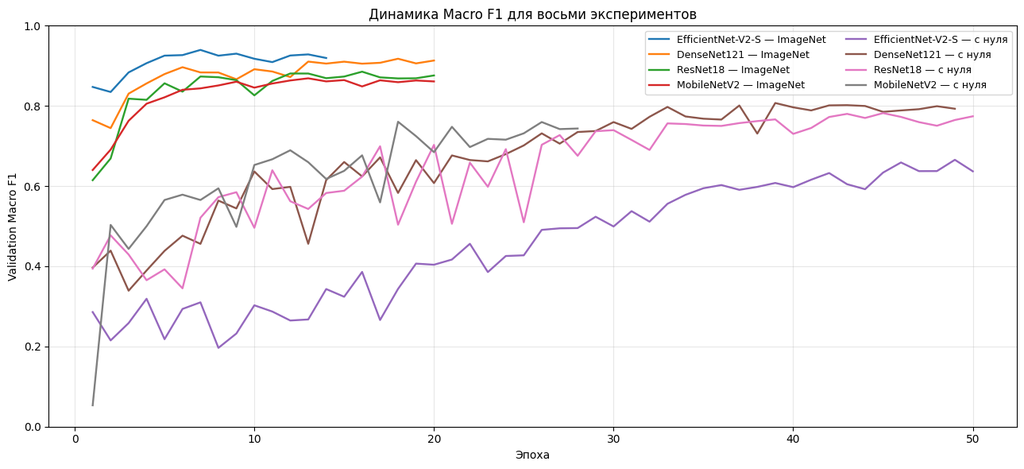

|  | model | mode | epochs | best_epoch | val_macro_f1 | val_accuracy | minutes |
| --- | --- | --- | --- | --- | --- | --- | --- |
| 0 | EfficientNet-V2-S | pretrained | 14 | 7 | 0.939598 | 0.952507 | 14.190967 |
| 1 | DenseNet121 | pretrained | 20 | 18 | 0.917619 | 0.939314 | 9.273884 |
| 2 | ResNet18 | pretrained | 20 | 16 | 0.885356 | 0.907652 | 6.203623 |
| 3 | MobileNetV2 | pretrained | 20 | 13 | 0.868774 | 0.894459 | 5.557416 |
| 5 | DenseNet121 | scratch | 49 | 39 | 0.807173 | 0.831135 | 25.546264 |
| 6 | ResNet18 | scratch | 50 | 45 | 0.782015 | 0.804749 | 16.433654 |
| 7 | MobileNetV2 | scratch | 28 | 18 | 0.760434 | 0.773087 | 8.373821 |
| 4 | EfficientNet-V2-S | scratch | 50 | 49 | 0.665546 | 0.725594 | 54.341134 |

```python
fig, ax = plt.subplots(figsize=(13, 6))
for model_name, mode in EXPERIMENTS:
    last_path, _ = checkpoint_paths(model_name, mode)
    if not last_path.exists():
        continue
    saved = torch.load(last_path, map_location='cpu', weights_only=True)
    history = saved.get('history', [])
    if not history:
        continue
    ax.plot([row['epoch'] for row in history], [row['val_f1'] for row in history],
            label=f'{model_name} — {"ImageNet" if mode == "pretrained" else "с нуля"}',
            linewidth=1.7)
ax.set(xlabel='Эпоха', ylabel='Validation Macro F1',
       title='Динамика Macro F1 для восьми экспериментов', ylim=(0, 1))
ax.grid(alpha=0.3)
ax.legend(ncol=2, fontsize=9)
plt.tight_layout()
plt.savefig(output_dir / 'validation_macro_f1.png', dpi=160)
plt.show()

summary_rows = []
for name, mode in EXPERIMENTS:
    last_path, _ = checkpoint_paths(name, mode)
    if not last_path.exists():
        continue
    saved = torch.load(last_path, map_location='cpu', weights_only=True)
    if saved.get('completed'):
        summary_rows.append(saved['summary'])
if summary_rows:
    summary_df = pd.DataFrame(summary_rows).sort_values('val_macro_f1', ascending=False)
    display(summary_df)
    summary_df.to_csv(output_dir / 'validation_summary.csv', index=False)
```

## 8. Итоговая проверка на Test

Выбираем лучшие веса **по валидационному Macro F1**. Затем измеряем Macro F1 и accuracy на Test и строим сравнительную столбчатую диаграмму. Тестовый результат не участвует в обновлении весов или выборе эпохи. Для полноценного отчёта нужны все восемь завершённых экспериментов.

```
EfficientNet-V2-S_pretrained   | Test F1 0.9464 | Test accuracy 95.26%
DenseNet121_pretrained         | Test F1 0.9423 | Test accuracy 94.21%
ResNet18_pretrained            | Test F1 0.9249 | Test accuracy 93.16%
MobileNetV2_pretrained         | Test F1 0.9026 | Test accuracy 90.79%
EfficientNet-V2-S_scratch      | Test F1 0.5998 | Test accuracy 63.42%
DenseNet121_scratch            | Test F1 0.7735 | Test accuracy 77.89%
ResNet18_scratch               | Test F1 0.7645 | Test accuracy 78.68%
MobileNetV2_scratch            | Test F1 0.7374 | Test accuracy 74.21%
```

|  | model | mode | best_epoch | val_macro_f1 | test_macro_f1 | test_accuracy |
| --- | --- | --- | --- | --- | --- | --- |
| 0 | EfficientNet-V2-S | pretrained | 7 | 0.939598 | 0.946389 | 0.952632 |
| 1 | DenseNet121 | pretrained | 18 | 0.917619 | 0.942264 | 0.942105 |
| 2 | ResNet18 | pretrained | 16 | 0.885356 | 0.924949 | 0.931579 |
| 3 | MobileNetV2 | pretrained | 13 | 0.868774 | 0.902639 | 0.907895 |
| 5 | DenseNet121 | scratch | 39 | 0.807173 | 0.773483 | 0.778947 |
| 6 | ResNet18 | scratch | 45 | 0.782015 | 0.764490 | 0.786842 |
| 7 | MobileNetV2 | scratch | 18 | 0.760434 | 0.737383 | 0.742105 |
| 4 | EfficientNet-V2-S | scratch | 49 | 0.665546 | 0.599842 | 0.634211 |

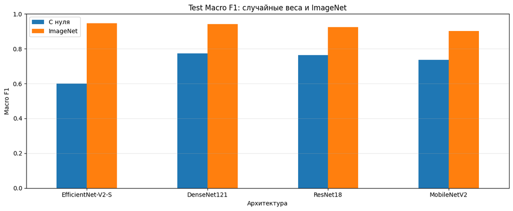

```python
completed = []
for model_name, mode in EXPERIMENTS:
    last_path, _ = checkpoint_paths(model_name, mode)
    if last_path.exists():
        state = torch.load(last_path, map_location='cpu', weights_only=True)
        if state.get('completed', False):
            completed.append((model_name, mode))

if len(completed) != len(EXPERIMENTS):
    print(f'Завершено {len(completed)} из 8 экспериментов. '
          'Тестирование отложено до завершения всех восьми.')
else:
    test_results_path = output_dir / 'test_results.json'
    test_results = json.loads(test_results_path.read_text(encoding='utf-8')) if test_results_path.exists() else {}
    for model_name, mode in EXPERIMENTS:
        key = f'{model_name}_{mode}'
        if key in test_results:
            print(f'{key}: тест уже выполнен.')
            continue
        _, best_path = checkpoint_paths(model_name, mode)
        checkpoint = torch.load(best_path, map_location='cpu', weights_only=True)
        model = build_model(model_name, pretrained=False).to(device)
        model.load_state_dict(checkpoint['model'])
        _, _, test_loader = get_loaders(model_name)
        test_metrics = evaluate(model, test_loader)
        test_results[key] = dict(
            model=model_name, mode=mode,
            best_epoch=int(checkpoint['epoch']),
            val_macro_f1=float(checkpoint['val_f1']),
            test_macro_f1=float(test_metrics['macro_f1']),
            test_accuracy=float(test_metrics['accuracy']),
        )
        test_results_path.write_text(
            json.dumps(test_results, ensure_ascii=False, indent=2), encoding='utf-8')
        print(f'{key:30s} | Test F1 {test_metrics["macro_f1"]:.4f} '
              f'| Test accuracy {test_metrics["accuracy"]:.2%}', flush=True)
        del model, test_loader
        gc.collect()
        if USE_AMP:
            torch.cuda.empty_cache()

    result_df = pd.DataFrame([test_results[f'{n}_{m}'] for n, m in EXPERIMENTS])
    display(result_df.sort_values('test_macro_f1', ascending=False))
    result_df.to_csv(output_dir / 'test_results.csv', index=False)

    pivot = result_df.pivot(index='model', columns='mode', values='test_macro_f1').loc[MODEL_NAMES]
    ax = pivot[['scratch', 'pretrained']].plot.bar(figsize=(12, 5), rot=0)
    ax.set(title='Test Macro F1: случайные веса и ImageNet',
           xlabel='Архитектура', ylabel='Macro F1', ylim=(0, 1))
    ax.legend(['С нуля', 'ImageNet'])
    ax.grid(axis='y', alpha=0.3)
    plt.tight_layout()
    plt.savefig(output_dir / 'test_macro_f1_comparison.png', dpi=160)
    plt.show()
```

## 9. Матрица ошибок лучшей по валидации модели

Для анализа редких классов показываем матрицу ошибок и F1 каждого класса. Лучший эксперимент определяется по **валидации**, не по тесту.

```
Лучшая по валидации: EfficientNet-V2-S pretrained
Test Macro F1: 0.9464
              precision    recall  f1-score   support

   cardboard       0.98      0.95      0.97        60
       glass       0.96      0.96      0.96        76
       metal       0.94      1.00      0.97        62
       paper       0.97      0.97      0.97        89
     plastic       0.93      0.90      0.92        73
       trash       0.90      0.90      0.90        20

    accuracy                           0.95       380
   macro avg       0.95      0.95      0.95       380
weighted avg       0.95      0.95      0.95       380
```

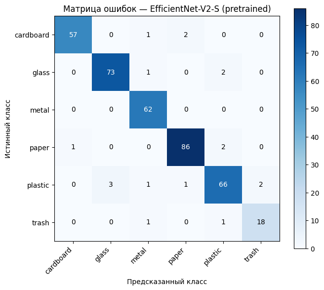

```python
if len(completed) == len(EXPERIMENTS):
    best_pair = max(EXPERIMENTS, key=lambda pair: next(
        row['val_macro_f1'] for row in summary_rows
        if row['model'] == pair[0] and row['mode'] == pair[1]
    ))
    best_name, best_mode = best_pair
    _, best_path = checkpoint_paths(best_name, best_mode)
    checkpoint = torch.load(best_path, map_location='cpu', weights_only=True)
    model = build_model(best_name, pretrained=False).to(device)
    model.load_state_dict(checkpoint['model'])
    _, _, test_loader = get_loaders(best_name)
    metrics, y_true, y_pred = evaluate(model, test_loader, return_labels=True)
    matrix = confusion_matrix(y_true, y_pred, labels=range(NUM_CLASSES))
    print('Лучшая по валидации:', best_name, best_mode)
    print('Test Macro F1:', round(metrics['macro_f1'], 4))
    print(classification_report(y_true, y_pred, labels=range(NUM_CLASSES),
                                target_names=class_names, zero_division=0))
    fig, ax = plt.subplots(figsize=(7, 6))
    display_matrix = ax.imshow(matrix, cmap='Blues')
    fig.colorbar(display_matrix, ax=ax)
    ax.set_xticks(range(NUM_CLASSES), labels=class_names, rotation=45, ha='right')
    ax.set_yticks(range(NUM_CLASSES), labels=class_names)
    ax.set(xlabel='Предсказанный класс', ylabel='Истинный класс',
           title=f'Матрица ошибок — {best_name} ({best_mode})')
    for i in range(NUM_CLASSES):
        for j in range(NUM_CLASSES):
            ax.text(j, i, str(matrix[i, j]), ha='center', va='center',
                    color='white' if matrix[i, j] > matrix.max() / 2 else 'black')
    plt.tight_layout()
    plt.savefig(output_dir / 'confusion_matrix.png', dpi=160)
    plt.show()
    del model
    if USE_AMP:
        torch.cuda.empty_cache()
else:
    print('Матрица ошибок появится после завершения всех экспериментов.')
```

## Вывод

Сравнить Macro F1 четырёх архитектур в двух режимах и объяснить влияние предобученных весов ImageNet на качество и скорость сходимости. Отдельно отметить размер модели и особенности архитектуры. Для маленького несбалансированного датасета Macro F1 информативнее одной лишь accuracy.

**Ограничение эксперимента:** режимы имеют разные бюджеты эпох и learning rate, поэтому мы сравниваем практические стратегии обучения, а не исключительно влияние начальных весов при прочих полностью одинаковых гиперпараметрах. Кроме того, данный тестовый split ранее использовался в исследовательских запусках — итоговые цифры не следует считать независимой оценкой выбора архитектур.